# Line2D

# Line2D draws lines

The `Line2D` node is a versatile node that can significantly enhance the visual appeal of your games. It can be a robust prototyping tool for drawing paths, bullets, ropes, lasers, and much more.

In this guide, you will learn how to:

- Set up a `Line2D`.
- Use a `Line2D` for an outline and drawing paths.
- Make *Bullet* trails and arcs.
- Draw simple ropes for physics games.

Contents:

- Setting up a Line2D
- Line2D’s key features
  - Width and Width Curve
  - Default Color and Fill Gradient
  - Texture and Texture Mode
  - Capping
  - Border
- How to use a Line2D in practice
  - Polygon Outline
  - Bullet trails
  - Projectile paths
  - Previewing paths
  - Tether
  - Homing projectiles
- Your questions
  - Converting a PoolVector2Array into a regular Array
  - Animated and Tiling textures
  - Inserting points into a line
  - Making a laser beam

## Setting up a Line2D

A `Line2D` needs a series of points showing where the `Line2D` is visible.

These points are in the *Points* property: a `PoolVector2Array`. This data type is an `Array` for points in 2D space.

You can add these points manually in the inspector or add them in the `Viewport` using the *Create Points*, *Edit Points*, and *Erase Points* buttons on the toolbar.

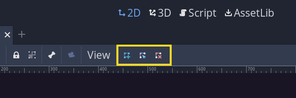

These points are local vectors, so moving the `Line2D` node offsets all the points accordingly.

**Note:** You can update the *Points* property in code. Many of the following demos cover updating points in this way.

## Line2D’s key features

### Width and Width Curve

You can customize the width of a line to be a set number of pixels with the *Width* property.

This width is constant across the length of the line. If you want the width to vary, you can use the *Width Curve* property.

This curve lets you define how thin or thick the line should be as you go from one end to the other.

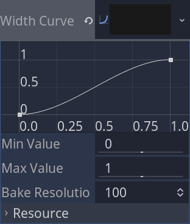

When using the *Width Curve*, the line’s width is proportional to its values.

If you have a *Width* of `30.0` pixels and your *Width Curve* ends with a value of `0.5`, the last point of your line will have a width of `30.0 * 0.5 = 15.0` pixels.

Usually, you would want to set a linear or smooth-step curve making your line into an arrow of some kind.

### Default Color and Fill Gradient

There are three ways you can control the color of your line.

1. The *Default Color* property.
2. *Modulate* and *Self Modulate*.
3. *Fill Gradient*.

*Fill Gradient* allows you to define a color gradient that applies to your line.

You can make one end of the line fade out by making one end of the `Gradient` transparent.

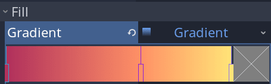

The gradient stretches along the line, regardless of the number of points or the line’s length.

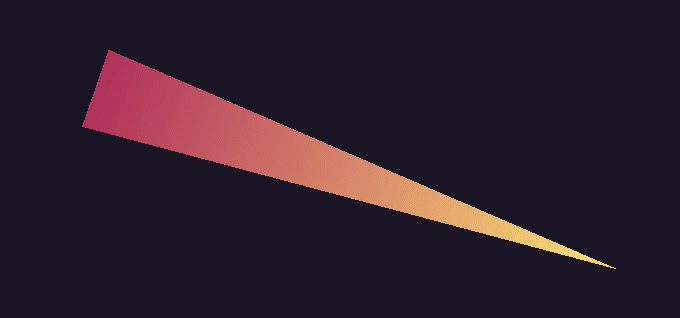

**Note:** If you are setting the color of your `Line2D` with code, there are several premade colors to choose from. You can view these in the [Godot Docs for the Color class.](https://docs.godotengine.org/en/stable/classes/class_color.html)

### Texture and Texture Mode

If a flat color or gradient doesn’t provide the line effect you want, you have the option to use textures instead. This opens up many possibilities for powerful visual effects!

When you add a texture to your line, there are two key modes to fit it to the shape of the line: *Tile* and *Stretch*.

The *Tile* repeats your texture to fill the space when the base texture isn’t wide enough. This mode is useful because it won’t distort the texture, so long as the texture looks intended to repeat.

Make sure you use the *Import* dock to enable repeating on your texture. You can do this by setting *Import -> Flags -> Repeat -> Enabled* after selecting the texture.

*Stretching* is your other choice. It makes your texture stretch to fit the space.

This distorts and blurs the pixels on the texture, but you can remove the blur by disabling *Import -> Flags -> Filter*.

### Capping

By default, the `Line2D` is rectangular with a flat edge at the front and back. If you want either end to be round instead, there are separate capping modes for each end.

You control `Line2D` caps using the *Capping -> Begin Cap Mode* and *End Cap Mode* properties. They both have two settings each:

- *Box* gives an extended flat edge to the line end.
- *Round* creates a semi-circular edge.

Capping -> *Joint Mode* controls the corners of the line:

- *Sharp* creates boxy corners.
- *Round* creates circular corners.
- *Bevel* smooths off the corners with an additional angular line.

### Border

There are a few options for fine-grain control over the appearance of your `Line2D`. If your *Joint Mode* is *Sharp*, you can use the *Sharp Limit* property. This property determines how extreme an angle is allowed before Godot should cut off a corner.

[figure not shown]

If your *Joint Mode* is set to *Round*, you can customize how many subdivisions create the circular edge with the *Border -> Round Precision* property.

This property determines how many vertices Godot draws when drawing the rounded edges. The higher the number, the more accurate the rounded edge.

Finally, you have the option to enable *Border -> Antialiased*, which helps reduce jagged edges.

## How to use a Line2D in practice

### Polygon Outline

If your game’s visuals use many simple geometric shapes, `Line2D` can help extend this geometric theme.

A geometric theme can help speed up prototype-creation for your games while looking attractive, as seen in games like *Super Hexagon* and *The Impossible Game*:

[figure not shown]

*Game: Super Hexagon (2012)*

One node that works well for the geometric theme is `Polygon2D`. It has a *Points* property, just like a `Line2D`.

We can copy the points array from `Polygon2D` to a `Line2D` at the same position to create a border for a solid shape.

```
onready var _line: Line2D = $Polygon2D/Line2D
onready var _polygon: Polygon2D = $Polygon2D


    # Give the polygon the new points and update the line to the same
    _polygon.polygon = shape_list.front().points
    _line.points = _polygon.polygon
```

There are lots of tools at your disposal for customizing the appearance of your outline. We can round the edges and invert the color of the polygon for the color of our line:

```
    var random_index := rand_range(0, colors.size())
    _polygon.color = colors[random_index]
    _line.default_color = colors[wrapi(random_index + 1, 0, colors.size())]
```

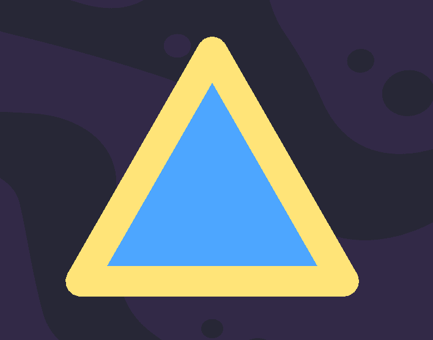

### Bullet trails

Flashy projectiles are a big selling point for many shooters. All types of projectiles can benefit greatly from using `Line2D` to draw things like bullet trajectory, the arc of a laser, or the trail left behind a missile.

[figure not shown]

*Game: Lovers in a Dangerous Spacetime (2015)*

Making a trail for a bullet involves taking the bullet’s global space and adding the space as a new point to a `Line2D`. We repeat this as the bullet moves while removing old points after enough time has passed.

In this example, we have a projectile. It calls `set_as_toplevel(true)` to move independently from its parent. It continually moves in a single direction until it collides or a timer deletes it.

```
const SPEED := 2500.0

var direction := Vector2.ZERO

onready var _particles := $Particles2D
onready var _timer := $Timer


func _ready() -> void:
    set_as_toplevel(true)


func _process(delta: float) -> void:
    position += direction * delta * SPEED


func _on_Timer_timeout() -> void:
    queue_free()


func _on_Area2D_body_entered(_body: Node) -> void:
    set_process(false)
    _particles.restart()
    _timer.start(1.0)
```

This bullet has a `Line2D` as a child on which we call `set_as_toplevel(true)`. This way, the `Line2D` node doesn’t inherit the bullet’s local position because our code will draw the line independently using global coordinates instead.

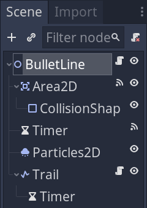

This bullet trail needs a `NodePath` to its parent since it uses its parent’s global position to draw the trail. We also set a maximum number of points to draw. There is also a timer included which removes old points.

```
extends Line2D

export var max_points := 16
export var target_path: NodePath

onready var target: Node2D = get_node_or_null(target_path)
onready var _timer: Timer = $Timer
```

We can set it as top-level in the `_ready()` function and move its position to the bullet we are tracing.

The core of the script is an update function triggered by the timer. This timer has *Autostart* enabled and *One shot* disabled, so it regularly emits the `timeout` signal.

```
func _ready() -> void:
    _timer.connect("timeout", self, "update_trail")
    set_as_toplevel(true)
    position = target.global_position
```

Every time the update occurs, we can add a point to our line at the projectile’s current relative position.

Then, when there are too many points, we can remove the oldest point.

```
func update_trail() -> void:
    add_point(to_local(target.global_position))
    if get_point_count() > max_points:
        remove_point(0)
```

All that’s needed now is for the `Line2D` to have a nice width curve to taper-off and fade out older points. With that, the effect is complete!

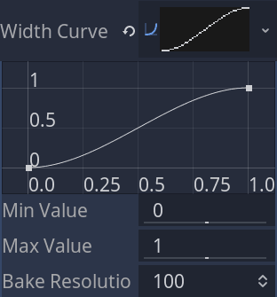

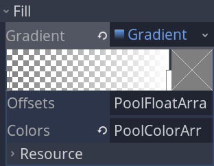

### Projectile paths

When firing projectiles, it can be helpful to preview the path the object follows, like in *Worms* or the bowling game in *Wii Sports*.

[figure not shown]

*Game: Wii Sports (2006)*

`Line2D` is the ideal node for this kind of problem, as you can quickly update it to travel in the same direction you are about to fire your projectile.

For our example, we have an asteroid that you can drag away from to fire in the opposite direction when you release your click.

When dragging, two lines appear. One indicates the force of the impending hit, and the other shows the direction of the asteroid’s path.

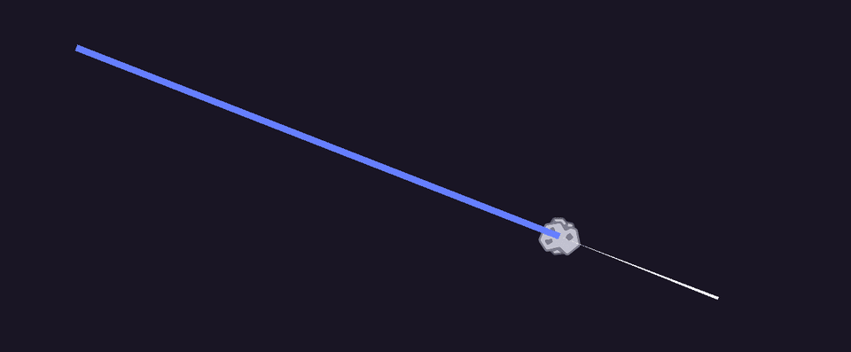

We can call `apply_impulse()` on the asteroid because it’s a `RigidBody2D`. For more about the specifics of launching objects around, check out the RigidBody2D guide.

Our `_process()` function updates the appearance of our lines in real-time. To that end, we need some input events: one to turn on process mode when the player clicks, and another to disable it when releasing the click.

```
func _unhandled_input(event: InputEvent) -> void:
    if event.is_action_pressed("pull_object"):
        set_process(true)
    elif event.is_action_released("pull_object"):
        hit_putt(_trajectory.points[1])
        set_process(false)
        # Reset the points of our line, to hide them when the click is released.
        _line.points[1] = Vector2.ZERO
        _trajectory.points[1] = Vector2.ZERO
```

Now, we can focus on updating our lines to preview information about the launch of our asteroid.

We use the `pow()` function to make our shot exponentially powerful if the mouse is further away from the target. We also subtract the local mouse position to move the line end opposite to where the mouse currently is.

```
func _process(_delta: float) -> void:
    var launch_force := get_local_mouse_position()
    var launch_power := launch_force.length()
    var launch_direction := launch_force.normalized()

    # We limit the force to prevent the player from drawing long lines and
    # sending the ball at absurd speeds.
    if launch_power > max_launch_power:
        launch_force = launch_direction * max_launch_power
        launch_power = max_launch_power

    # We turn the distance our mouse is from the player into a proportional
    # width indicating hit strength.
    _line.width = range_lerp(launch_power, 0.0, max_launch_power, 0.0, max_line_width)
    # We draw the hitting line from the mouse to the ball, limiting its length.
    _line.points[1] = launch_force
    # We draw the trajectory line, this caches how far we want to fire the
    # asteroid for later.
    _trajectory.points[1] = -launch_direction * pow(launch_power, 1.2)
```

The final step is to use the trajectory we just saved to our line and use that value to launch our asteroid.

With `linear_damp` set to `1.0` on our rigid body, a mass of `1.0`, and no gravity, our asteroid will travel to exactly where our trajectory indicates.

### Previewing paths

Many turn-based games with tile-based or restricted movement use a line to preview your character’s path to follow.

[figure not shown]

*Game: Mario + Rabbids Kingdom Battle (2017)*

Using `Line2D`, `Path2D`, and `Navigation2D`, it’s possible to create a preview of the player’s navigational path.

We created a scene with a character that moves on mouse clicks using `Navigation2D` and `NavigationPolygon`. We use this `Navigation2D` to generate a path, then draw it to a `Line2D` to preview the route to the player.

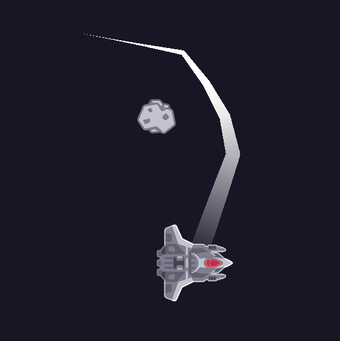

First, we need our scene with a prepared `Navigation2D`, `Line2D`, and a player ship. The ship has some specific methods we will get to in a moment.

```
onready var navigator: Navigation2D = $Navigation2D
onready var _line2d: Line2D = $Line2D
onready var _ship := $Ship
```

We can get a path from the ship to the mouse using the `Navigation2D` node in an `Input` event.

This path gets passed into our ship scene, as it has a `PathFollow2D` that needs the points.

We can then get the ship’s path to follow back from the ship and provide it to our `Line2D`.

```
func _unhandled_input(event: InputEvent) -> void:
    if Input.is_action_pressed("move_to_target"):
        var path: PoolVector2Array = navigator.get_simple_path(
            _ship.get_global_position() - global_position,
            get_global_mouse_position() - global_position
        )
        _ship.set_path(path)
        _line2d.points = _ship.get_curve_path()
        _ship.move_to(get_global_mouse_position())
```

Our ship scene is a `Path2D`, with a `PathFollow2D` as a child, then the ship itself. This structure makes handling predefined movement a breeze.

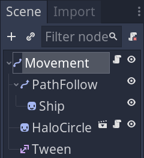

```
extends Path2D

const SPEED := 666.0
const MIN_LENGTH := 10.0

onready var _halo := $HaloCircle
onready var _tween := $Tween
onready var _path_follow := $PathFollow
```

Now we need to define the `set_path()` and `get_curve_path()` methods we used earlier.

Unfortunately, the points in a `Curve2D` aren’t available for us to assign to our `PoolVector2Array` directly. We need to clear the points in our curve and add each point using a `for` loop.

We can get a `PoolVector2Array` straight back out of our `Path2D` by calling `get_baked_points()` on the `Curve` resource.

```
func get_global_position() -> Vector2:
    return _path_follow.global_position


func get_curve_path() -> PoolVector2Array:
    return curve.get_baked_points()


func set_path(path: PoolVector2Array) -> void:
    curve.clear_points()
    for point in path:
        curve.add_point(point)
```

Finally, we need to use an animation to have our player follow the path we just made. A `Tween` is perfect for this kind of procedural animation. We need to increase our *Unit Offset* property of the `PathFollow2D` from `0.0` to `1.0`.

```
func move_to(target_position: Vector2) -> void:
    _tween.remove_all()

    _halo.global_position = target_position
    _tween.interpolate_property(_halo, "size", 0, 100, 1.0)
    _tween.interpolate_property(_halo, "modulate", Color.white, Color.transparent, 1.0)
    _tween.interpolate_property(
        _path_follow, "unit_offset", 0.0, 1.0, curve.get_baked_length() / SPEED
    )
    _tween.start()
```

### Tether

`Line2D` is ready-made to represent thin objects like ropes, wires, tethers, and chains.

[figure not shown]

*Game: Cut the Rope (2010)*

We can use a `Line2D` to show the connection between a player and a balloon attached with a `DampedSpringJoint2D`.

[figure not shown]

The process is a matter of setting the position of the line to one of the objects. Then you can update a point on the line to be the position of the connected target.

First, let’s set up our scene with the player and balloon.

This interaction involves built-in physics, so we should use a `RigidBody2D` for our player and the balloon. For more information about setting up a physics-based player like this, see the RigidBody2D guide.

This player needs a few key children:

- `DampedSpringJoint2D` to connect the player and the balloon.
- `RigidBody2D` for the balloon.
- `Line2D` as a child of the balloon as the rope between them.

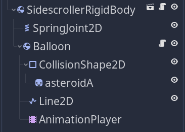

Then we can position the joint between the player and the balloon and set both rigid bodies on the joint.

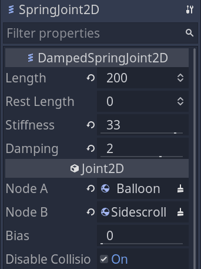

That is enough to get the balloon working and lifting the player, so let’s focus on the rope’s appearance.

The line is a child of our balloon, so we know one end of the line is at the correct point on the balloon. So we need to draw the other end towards where the player is.

In `Line2D`’s *Points*, we give its `PoolVector2Array` to have two points, both at `Vector2.ZERO`.

In the balloon’s script in each `_process()` step, we can set one of those points to be the player’s relative position. You can find the relative position between a node and a global position with the `to_local()` method.

Finally, to add some more liveliness to the scene, we can update the width of the rope so it is thinner when the string has less room to stretch, as the balloon and player are far apart.

We can turn the distance into a sanitized distance by using a `range_lerp()`. This function lets you take a point in a range and map it onto the equivalent point in another range, so as our distance goes from `0.0` to `500.0` pixels, our width should go from `50.0` to `5.0` pixels.

```
const MIN_LENGTH := 5.0
const MAX_LENGTH := 50.0

export var player_path: NodePath

onready var _player := get_node(player_path)
onready var _animation_player: AnimationPlayer = $AnimationPlayer
onready var _line: Line2D = $Line2D


func _process(_delta: float) -> void:
    _line.points[1] = to_local(_player.global_position)
    _line.width = range_lerp(_line.points[1].length(), 0.0, 500.0, MAX_LENGTH, MIN_LENGTH)
```

### Homing projectiles

For many reasons, you may want to draw a curve rather than a straight line. By taking advantage of a `Path2D`’s `Curve` resource, you can easily generate a curved line.

We can use this to draw a homing projectile that arcs to a target.

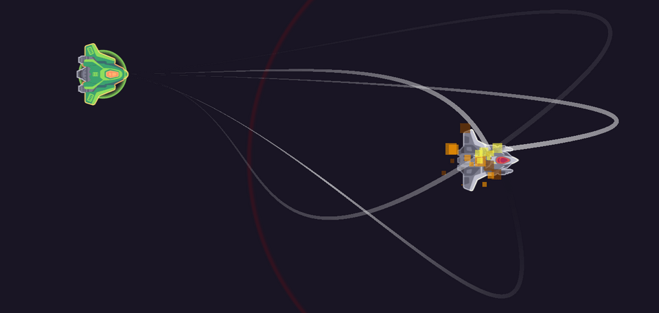

We have a weapon attached to our player that instances a homing projectile `packed_scene` when the player presses the shoot action.

```
export var arc_scene: PackedScene
export var enemy_path: NodePath

onready var _enemy := get_node(enemy_path)
```

This projectile needs two things: the target’s position, and the direction in which the projectile should fire.

We can then pass these through a `fire()` function we define in the projectile script.

```
    var shoot_vector = Vector2.UP.rotated(global_rotation)
    var arc = arc_scene.instance()

    add_child(arc)
    arc.fire(global_position, _enemy.global_position, shoot_vector)
```

Our projectile has a path to create our curved path, the `Line2D` to draw our shot, and an `AnimationPlayer` to add visual flair to the effect.

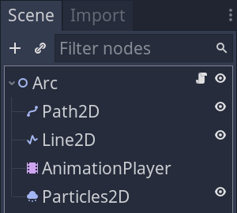

As with most projectiles, we want to use the `set_as_toplevel()` function to make the arc not move with the player that fired it.

```
onready var _path := $Path2D
onready var _line := $Line2D
onready var _particles := $Particles2D
onready var _animation_player := $AnimationPlayer


func _ready() -> void:
    set_as_toplevel(true)
    randomize()
```

Now we can get to the nuts and bolts of setting up our curve.

When adding points to a curve, you can provide in and out control points. These determine how to curve the line in question.

We pass in our firing direction to use as a control point. This makes our gunfire in the correct direction to start with then arc around to the target.

```
func fire(origin: Vector2, target: Vector2, direction_in: Vector2) -> void:
    global_position = origin
    # Save the distance from the player to the target to figure out how wide our curve should arc.
    var vector_strength := origin.distance_to(target)
    # Offseting the target position slightly will make our shots look less robotic, hitting slightly around the target.
    var endpoint: Vector2 = target + get_random_vector(sqrt(vector_strength))
    # To generate our curve, we add our start and end points with in and out control points to control the curve.
    # We use direction_in, to have our curve start firing in the same direction the player is aiming at first.
    _path.curve.add_point(
        Vector2.ZERO,
        get_random_vector(vector_strength),
        direction_in * vector_strength * 0.5
    )
    # The target point has completely randomised control points, to create unique firing arcs.
    _path.curve.add_point(
        # Get the local position of the target to fire to
        to_local(endpoint),
        get_random_vector(vector_strength),
        get_random_vector(vector_strength)
    )
    # Now our curve is set up, we can convert it into a series of points for our Line2D
    _line.points = _path.curve.get_baked_points()
    # Put particles at the end and play our firing animation.
    _particles.global_position = endpoint
    _animation_player.play("Fire")


## Returns a random Vector2 from an input strength
func get_random_vector(strength_in: float) -> Vector2:
    return Vector2(
        rand_range(-strength_in, strength_in),
        rand_range(-strength_in, strength_in)
    )
```

To achieve the visual effect we did with the arcing projectile, you can take advantage of the gradient property of your `Line2D`.

We have a gradient with three points: one transparent, one white, and another transparent. This makes a white gradient that fades out at both edges.

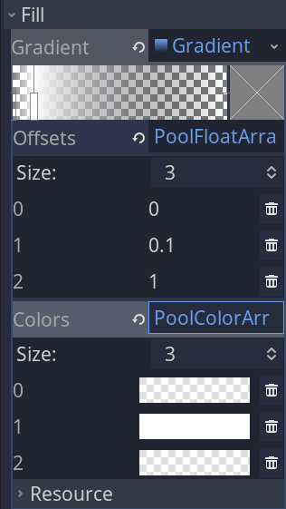

In an `AnimationPlayer`, you can animate the offset of the middle point in the `Gradient` to move from one end to another.

Make it fast, have the whole line fade out afterward, and you have an awesome projectile.

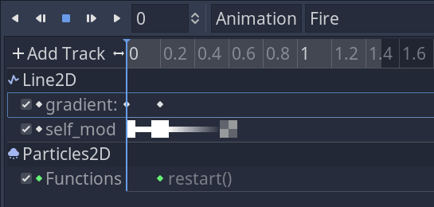

## Your questions

### Converting a PoolVector2Array into a regular Array

You can cast all of Godot’s specific array types to regular arrays to get access to all of the powerful built-in `Array` processing functions like `push_back()`, `pop_front()`, and `shuffle()`.

You can do this by passing your `PoolVector2Array` into an `Array` constructor:

```
var point_array := Array($Line2D.points)
```

### Animated and Tiling textures

As with all textures in Godot, you can create an animated texture resource to use in its place. Just select `AnimatedTexture` as your texture resource, choose the number of frames, and add textures as those frames.

This can be an easy way to make your projectiles that use a `Line2D` much more captivating, but be careful to properly make your flipbook animation tile.

### Inserting points into a line

If you have a point you want to insert at a specific index in a `Line2D`, the `add_point()` function has an extra optional parameter: `at_position`. This defaults to `-1`, indicating that Godot should add points at the end of the points array.

If you provide a valid index in `at_position`, Godot adds your point before that position, and every following point has its index increased by one.

### Making a laser beam

A `Line2D` is ideal for creating beam weapons like lasers. For a complete guide on lasers, check out the RayCast2D guide.